# PCA on zebrafish test compendium

J. Taroni for CCDL

2019

Here, we’re using a large zebrafish test compendium that was run in production. It’s majority RNA-seq data. We had early results using a small test compendium that suggested there was a notable “platform bias” when using PCA. We’ll perform PCA on the large compendium in this notebook with particular regard for technology.

## Setup

#### Packages and functions

```r
library(ggfortify)
```

```r
`%>%` <- dplyr::`%>%`
```

#### Directories/files

```r
test_compendium_dir <- file.path("refinebio-data", "larger-compendium",
                                 "DANIO_RERIO")
compendium_exprs_file <- file.path(test_compendium_dir, "DANIO_RERIO.tsv")
```

Directory for plots

```r
plot_dir <- "plots"
dir.create(plot_dir, showWarnings = FALSE)
```

## Main

Reading in the compendium expression data

```r
compendium_exprs_df <- readr::read_tsv(compendium_exprs_file,
                                       progress = FALSE)
```

We can *infer* which technology a sample is “part of” from the column names of this `data.frame`.

```r
set.seed(125)
sample(colnames(compendium_exprs_df), 6)
```

```
[1] "ERR1107982" "GSM1422785" "ERR1415040" "ERR998371"  "SRR6494611" "SRR1565820"
```

RNA-seq samples will have `ERR`, `SRR`, or `DRR` in their identifiers (column names). Let’s generate *labels* for the samples using this information.

```r
sample_names <- compendium_exprs_df %>%
  dplyr::select(-X1) %>%  # don't want gene id column
  colnames()
compendium_technology_labels <- rep("MICROARRAY", length(sample_names))
compendium_technology_labels[grep("ERR|DRR|SRR", sample_names)] <- "RNA-SEQ"
```

Get expression values as a matrix

```r
exprs_mat <- compendium_exprs_df %>%
  as.data.frame() %>%
  tibble::column_to_rownames("X1") %>%
  as.matrix()
saveRDS(exprs_mat, file.path("data", "larger_compendium_exprs_mat.RDS"))
```

### PCA

```r
pca_results <- prcomp(t(exprs_mat))
```

Prepare as `data.frame` for use elsewhere

```r
pc_df <- pca_results$x[, 1:2] %>%
  as.data.frame() %>%
  tibble::rownames_to_column("Sample")
```

```r
# get the technology labels as a data.frame for plotting
technology_df <- as.data.frame(compendium_technology_labels)
```

```r
technology_df %>%
  dplyr::mutate("Sample" = sample_names) %>%
  dplyr::inner_join(y = pc_df, by = "Sample") %>%
  readr::write_tsv(path = file.path("results",
                                    "larger_compendium_PC1and2.tsv"))
```

### Plotting

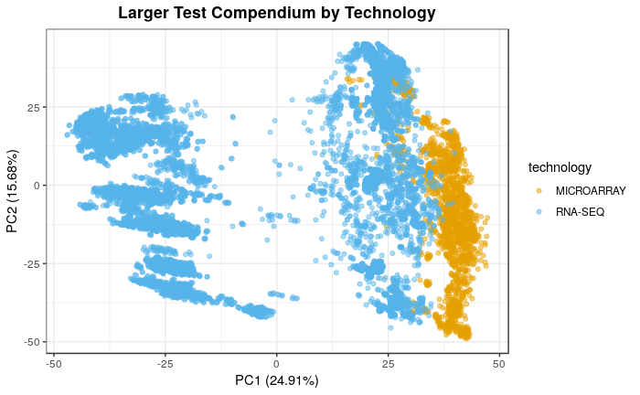

```r
# plotting with autoplot for PCA
autoplot(pca_results, data = technology_df, alpha = 0.5,
         colour = 'compendium_technology_labels', scale = 0) +
  scale_color_manual(labels = c("MICROARRAY", "RNA-SEQ"),
                     values = c("#E69F00", "#56B4E9")) +
  theme_bw() +
  ggtitle("Larger Test Compendium by Technology") +
  theme(plot.title = element_text(hjust = 0.5, face = "bold")) +
  guides(colour = guide_legend(title = "technology"))
```

We can see that there are some “clumps” in the RNA-seq, which, if I had to guess, likely correspond to samples from an individual experiment. *Here, I’m using the term “experiment” to refer to what is called a study (e.g., `SRP`, `ERP`, or `DRP`) in SRA.*

Save the plot to file.

```r
png(file.path(plot_dir, "larger_test_compendium_PCA_pairs_plot.png"))
p
```

```r
dev.off()
```